# atividade 4

Leonardo P. Migliorini

#### Ajuste modelo contínuo

Abaixo, temos o ajuste dos modelos encaixados considerando as variáveis altura, peso e idade como contínuas. Uma tabela para a Análise de Deviance (ANODEV) é apresentada abaixo:

Análise de Deviance entre os modelos

| Modelo | Resid. Df | Resid. Dev | Df | Deviance | Pr(>Chi) |
| --- | --- | --- | --- | --- | --- |
| Modelo 1: ~1 | 93 | 129.246 | NA | NA | NA |
| Modelo 2: ~altura | 92 | 47.788 | 1 | 81.458 | 0.000 |
| Modelo 3: ~altura + peso | 91 | 41.085 | 1 | 6.703 | 0.010 |
| Modelo 4: ~altura + peso + idade | 90 | 40.660 | 1 | 0.426 | 0.514 |

Pode-se observar que o modelo 2 apresentou diferença significativa no deviance em relação ao modelo nulo, indicando que a variável altura é importante para classificar o sexo dos alunos. Ainda o modelo 3 teve diferença significativa no deviance em relação ao modelo 2, indicando que a variável peso também é significativa para classificar o sexo dos alunos. Já a variável idade foi não significativa. Portanto, o modelo escolhido ao final é o modelo 3, cuja estrutura dos logitos é expressa por:

$$\begin{equation}
logito(\widehat{p}) = 81,38394 + -0,43835x_{i1} + -0,09863x_{i2},
\end{equation}$$

em que $x_{i1}$ representa a variável altura e $x_{i2}$ representa o peso.

Abaixo, temos os gráficos para os resíduos de Pearson e deviance para o modelo 3. Podemos ver que todos os valores estão entre $[-2,2]$ indicando um bom ajuste do modelo. Ainda, obtivemos as estatísticas $Q_{L} = 41,08545$ ($p-$valor $\approx 1$) e $Q_{P} = 47,82678$ ($p-$valor $\approx 1$) indicando também um bom ajuste do modelo 3.

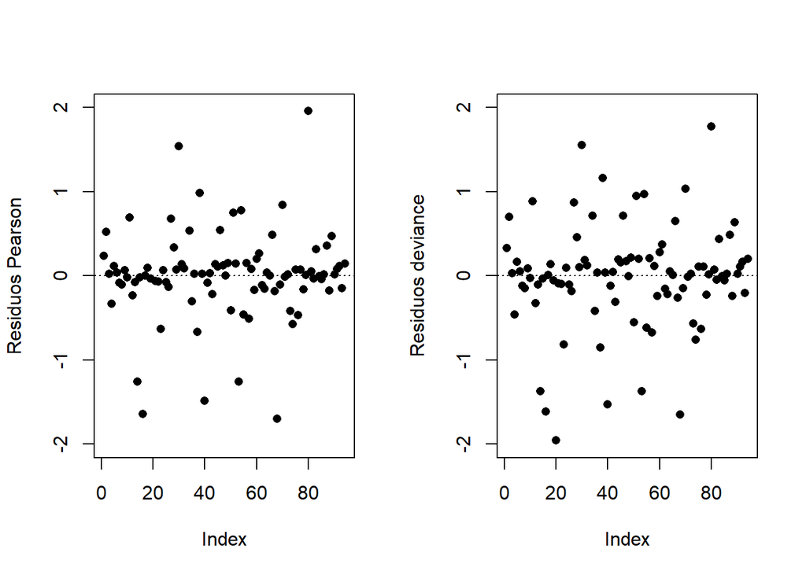

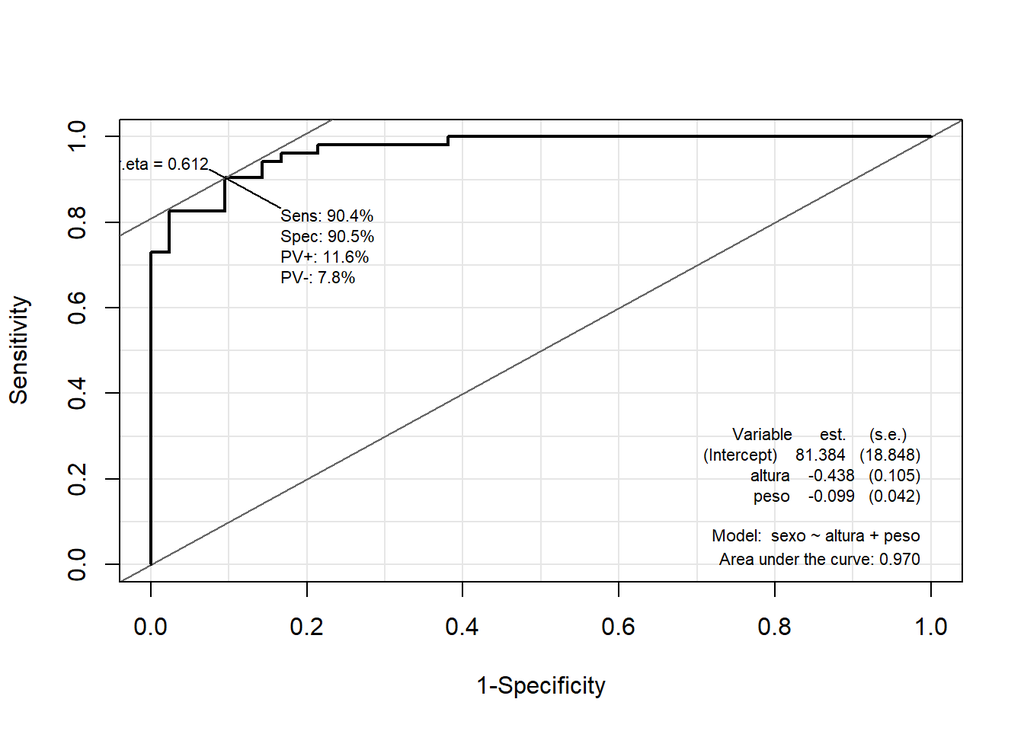

Quanto a interpretação dos coeficientes, serão omitidas, pois o efeito das covariáveis são mais difícies de serem calculadas quando as mesmas são contínuas. E a metodologia correta para esse caso, não foco da disciplina.

### Ajuste modelo categórico

Portanto, vamos ajustar novamente o modelo considerando dessa vez um corte na mediana de cada covariável. A idade foi dividida em alunos com menos de 238 meses mairoes ou iguais a 238 meses, o peso foi dividido em menores de 65Kg e mairoes ou iguais de 65Kg e a altura foi dividida em menores do que 169cm e mairoes ou iguais do que 169cm.

Abaixo, temos o ajuste dos modelos encaixados em uma tabela ANODEV.

Análise de Deviance entre os modelos

| Modelo | Resid. Df | Resid. Dev | Df | Deviance | Pr(>Chi) |
| --- | --- | --- | --- | --- | --- |
| Modelo 1: ~1 | 93 | 129.246 | NA | NA | NA |
| Modelo 2: ~altura | 92 | 59.708 | 1 | 69.538 | 0 |
| Modelo 3: ~altura + peso | 91 | 41.748 | 1 | 17.960 | 0 |
| Modelo 4: ~altura + peso + idade | 91 | 41.748 | 0 | 0.000 | NA |

Observa-se que tivemos a mesma escolha de ajustes para o caso anterior. No entanto a estrutura dos logitos para esse caso é dada por:

$$\begin{equation}
logito(\widehat{p}) = 4,9400 + -4,6661x_{i1} + -3,2760x_{i2}.
\end{equation}$$

Abaixo, temos os gráficos para os resíduos de Pearson e deviance para o modelo 3. Podemos ver que todos os valores continuam entre $[-2,2]$ indicando um bom ajuste do modelo. Ainda, obtivemos as estatísticas $Q_{L} = 41,74805$ ($p-$valor $\approx 1$) e $Q_{P} = 65,64573$ ($p-$valor $\approx 1$) indicando também um bom ajuste do modelo 3.

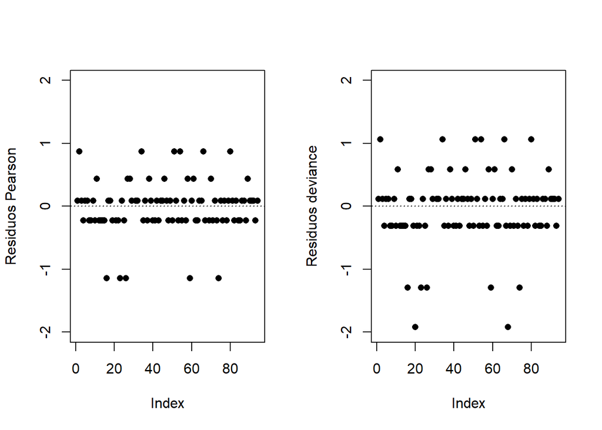

A curva ROC é idêntica ao ajuste anterior.

[figure not shown]

Interpretação das *odds ratio*:

Obtivemos uma *odds ratio* de 0,009 IC(0,001;0,066) para a altura ajustada ao peso. Ou seja, quanto maior a altura, menor a chance de ser do sexo feminino. Já para o peso ajustado a altura, obtivemos uma *odds ratio* de 0,038 IC(0,007;0,219). Ou seja, quanto maior o peso, menor a chance de ser do sexo feminino